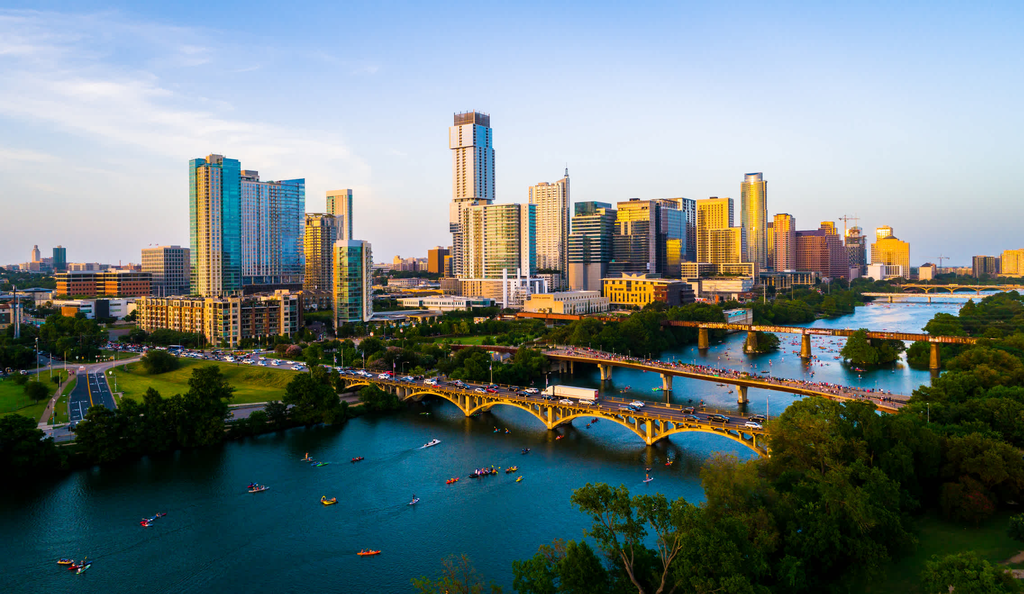

# Descriptive Statistics Project: sales analysis of real estate in Texas

Hello everyone, thank you for being here! :blush:

This is a project concerning the descriptive analysis of sales of real estate in Texas :house_with_garden:.

I used the dataset present in the `realestate_texas.csv` file. This consists of 240 observables of 8 variables, which give us information about the sales per month of the real estates of Beaumont, Bryan-College Station, Tyler and Wichita Falls, from 2010 to 2014. Going into detail, the variables are:

- `city`: reference city;
- `year`: reference year;
- `month`: reference month;
- `sales`: total number of sales;
- `listings`: total number of active listings;
- `volume`: total value of sales in millions of dollars;
- `median_price`: median sale price in dollars;
- `months_inventory`: amount of time required to sell all the active listings at the current sales rate, in months.